# Your Digest for Sunday, Sep 17, 2023 11:59 PM

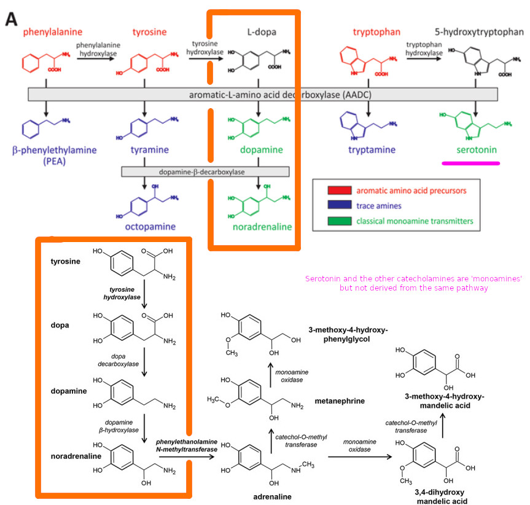

See also: figure 2 here: [Source](https://sci-hub.se/https://doi.org/10.1038/nrneurol.2015.172)

> "Almost right away after the stem cells are infused into your body, they’ll travel through your bloodstream to your bone marrow. They’ll start to divide and create healthy new blood cells. *Engraftment* is when your body accepts the transplant and your blood cell counts start to recover." [Source](https://www.mskcc.org/cancer-care/patient-education/allogeneic-stem-cell-transplantation)  
> GVHD can occur after allogenic haemotopoietic cell transplantation or with solid organs containing lymphoid tissue. (Bowel transplant was one example)  
> GVHD arises when immune cells transplanted from a non-identical donor (graft) into the recipient (host), recognize the *host cells* as "foreign," thereby initiating a graft-versus-host reaction.

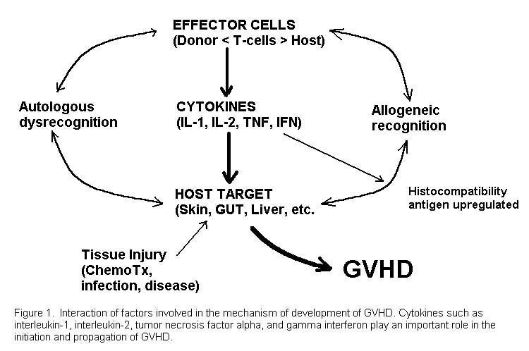

## Graft Vs. Leukemia effect

#2021BSQ-JUL Q05

> [!INFO] A kind of useful GVHD  
> Since donor cells tend to kill residual leukaemia cells, allogenic stem cell transplant is associated with reduced rate of recurrent of leukemia.

> Allogeneic hematopoietic stem cell transplantation (allo-SCT) is the most established and commonly used cellular immunotherapy in cancer care. It is the most potent anti-leukemic therapy in patients with acute myeloid leukemia (AML) and is routinely used with curative intent in patients with intermediate and poor risk disease. Donor T cells, and possibly other immune cells, eliminate residual leukemia cells after prior (radio)chemotherapy. This immune-mediated response is known as graft-versus-leukemia (GvL) - [Source](https://www.frontiersin.org/journals/oncology/articles/10.3389/fonc.2019.01217/full)

**Effective renal plasma flow** can be calculated using the Fick principle with para-amino hippuric acid. This is a substance that is filtered **and secreted** by the kidney (but not reabsorbed) meaning that almost all of it is removed in a pass through the kidney. (extraction ratio is aroun 90%).  
This yields a normal renal plasma flow of 625 ml/min.

> [!TIP] That's one tasty 625 ml

[figure not shown]

> Normal GFR = 125 ml / Min.

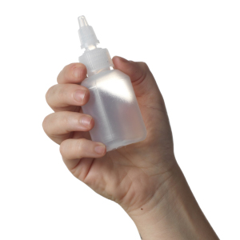

GFR is the volume of ultrafiltrate formed each minute.

> #2021BSQ-JUL Q10  
> Ideally, clearance should be measured using a substance which is freely filtered, not secreted and not reabsorbed. The ideal substance is *inulin*.  
> For such a substance, clearance would be equal to the GFR.

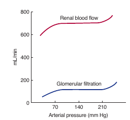

#2021BSQ-JUL Q10  
See this: [Source](http://eknygos.lsmuni.lt/springer/167/19-32.pdf)

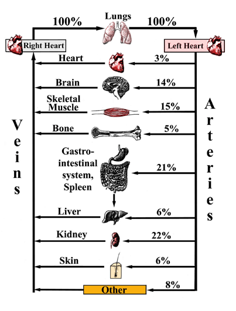

### Regulation of renal blood flow:

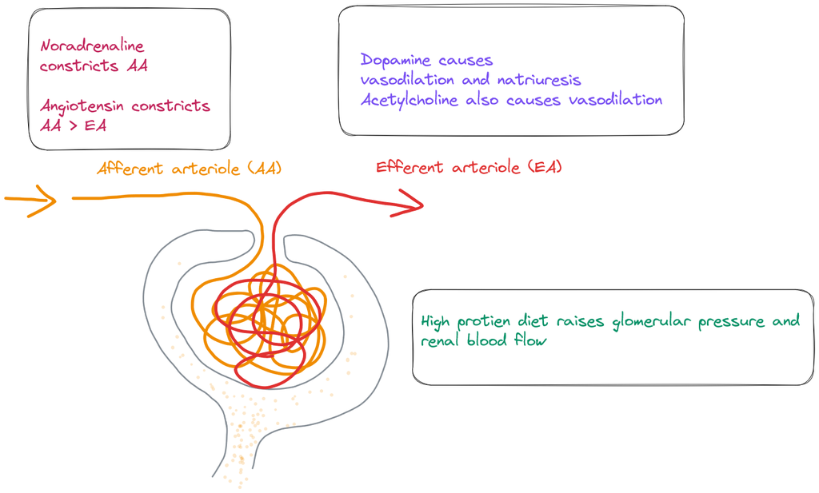

#2021BSQ-JUL Q07

# Indapamide

Is a thiazide like diuretic.  
It can be used in renal failure.  
Antihypertensive action is due to reduced peripheral vascular resistance, not due to diuresis.  
[Source](https://pubmed.ncbi.nlm.nih.gov/8172477/)

```
- All these drugs have the **same efficacy**
```

#2021BSQ-NOV Q36

# Cell injury

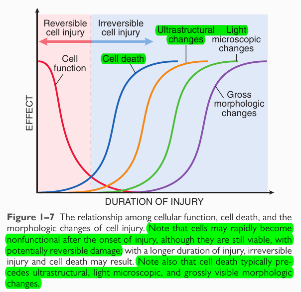

- Note that cellular malfunction *precedes* cell death. (i.e they don't have to die to stop working properly).
- Visible changes (even at EM level) only occur *after* cell 'death'.

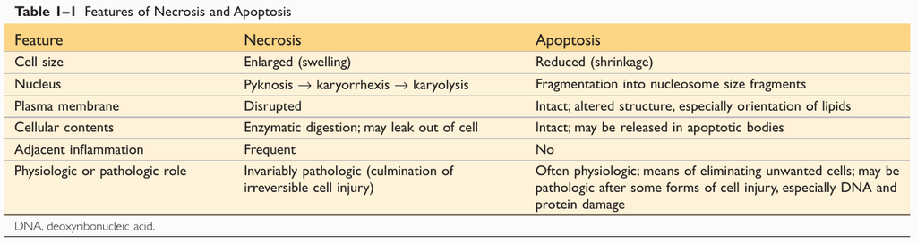

## Overview of cell injury

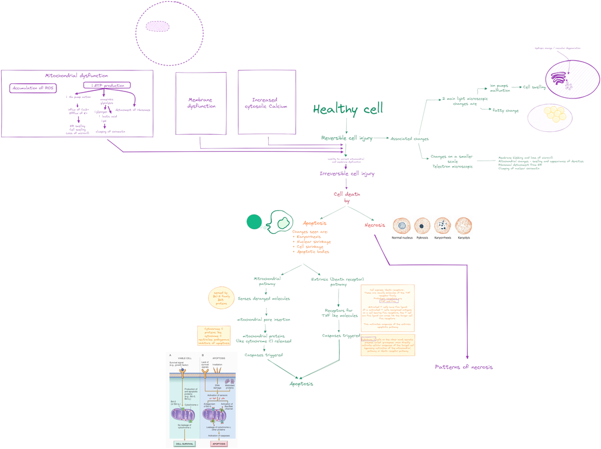

## vasoactive amines

Preformed mediators released from cells very quickly in reponse to inflmmation.

- Histamine
  - Stored in platelets, mainly mast cells, basophils
  - release triggered by physical damage, IgE crosslinking,
  - C3a and C5a - *anaphylatoxins*
  - Neuropeptides - Substance P
  - Cytokines like IL-1 and IL-8
  - leukocyte derived histamine releasing proteins.  
    Serotonin
- Biochemistry: [[adrenalineSynthesisMonoamines.jpg]]
- Preformed mediator released from platelet granules during platelet aggregation.
- Causes vasocontriction
- Also a neurotransmitter.

It's interesting to note that histamine and serotonin are both involved in nausea and emesis as their blockers are used as antiemetics.

[Source- NICE Guidelines](https://www.nice.org.uk/guidance/cg126/chapter/Guidance#anti-anginal-drug-treatment)

## What is stable angina?

> Angina is arbitrarily defined as stable when the angina episodes are stable over a *period of 3–6 months*.  
> Angina equivalents: Exertional SOB in absence of lung disease, extreme exertional fatigue; commoner in women, elderly and diabetes patients.  
> [Source](https://www.ncbi.nlm.nih.gov/pmc/articles/PMC6523058/)

Mortality is 2 - 3% per year.  
#2021BSQ-JUL Q12

1. Relieve symptoms
   1. Measures to treat an anginal episode
   2. Measure to prevent angina recurrences[[#antianginal medications]]
2. Preventing disease progression
   - Medication - **aspirin**, newer guidelines recommend ACEi as well (particular if patient has DM) [Source](https://www.nice.org.uk/guidance/cg126/chapter/Guidance#anti-anginal-drug-treatment)
   - Risk factor management - lipid lowering therapy - statins, smoking cessation, BP control, weight loss, optimal DM management, regular exercise, stress reduction etc.
3. Prevent future cardiac events (like ACS, death)

## Treating angina episodes

Short acting nitrate is the drug of choice.  
**Mechanism:** GTN causes coronary artery dilation and improves coronary blood flow. (but too much dilation will decrease blood pressure in vessels)

Repeat dose - 5 minutes.  
If pain doesn't settle 5 minutes after the second dose, call ambulance.

These second line antianginals are used only when

- The patient cannot tolerate one or both of the above drugs. If only one of the above isn't tolerated, add the 2nd line drug in combination.
- If the patient's angina *isn't controlled on two first line anti-anginals*, they are a candidate for revascularization. While they are waiting for revascularization, a second line antianginal can be added. (or if revascularization isn't an option)

Options:

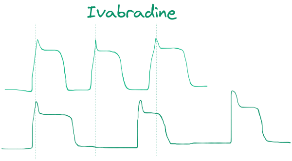

> [Source](https://www.ncbi.nlm.nih.gov/pmc/articles/PMC5933631/)
- Probably **no mortality benefit**. [Source](https://www.ncbi.nlm.nih.gov/pmc/articles/PMC5737998/)
7. Niconrandil: Potassium channel activator (K-ATP channel).
   1. Potassium channel activators dilate arterial smooth muscle.
   2. Nicorandil has nitrate groups as well so it also dilates veins.
   3. So arterial and venodilation exerts an antianginal effect.

> [!INFO] Misc updates  
> ACEi can be used to preventing ACS in aginal patients. [Source](https://www.escardio.org/Journals/E-Journal-of-Cardiology-Practice/Volume-15/Stable-angina-pectoris-which-drugs-or-combinations-to-use-in-which-patients)

#2021BSQ-JUL Q05

> Mnemonic : BPH - bradykning, prostaglandin and histamine act together.

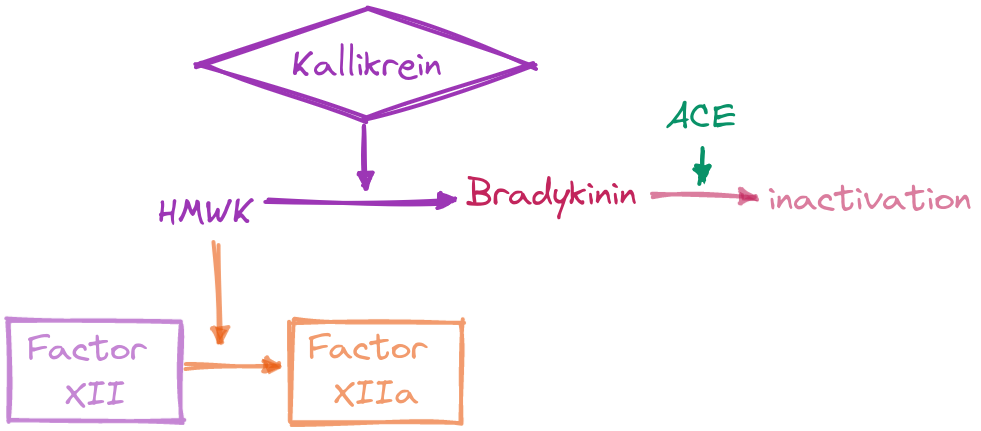

- **Crucial role in inflammation**.: 3 actions ->
  - ↑ HVasodilation -> increases blood flow
  - ↑ permeability -> oedema
  - ↑ sensitization of nociceptors -> pain
- A product of the *kinin cascade*. A poorly understood enzyme cascade in plasma, like the clotting cascade and complement cascade.
- Increases capillary permeability acting alongside **histamine** and **prostaglandin**;
- potent vasodilator. -> accumulation causes angiooedema and possibly the dry cough of ACEi therapy.
- Broken down by ACE and neprilysin.

### Hereditary angiooedema

#autosomalDominant  
C1 esterase deficiency.  
Episodes of angiooedema not responding to histamines or adrenaline, usually after a flu like prodrome.  
**No urticaria**.  
C1 esterase is a complement activation inhibitor.  
Defieciency of C1 esterase causes unchecked activation of C1, C2 and C4.  
This causes activation of kallikrein which causes increased production of bradykinin --> angiooedema.  
Low C2 and C4 levels are seen in hereditary angioedema.  
**Treatment:** *plasma derived C1 inhibitor.*

Mirtazapine - blocks presynaptic alpha receptors (increasing serotonin secretion) and post synaptic 5-HT2 and 5-HT3 recectors, leaving more serotonin for 5-HT1 receptors.